# Garimpo do Lorenço

## 6.1 Métricas por classe de mineração

Aqui vamos calcular todos as métricas por classe (função `calculate_lsm()`)).

```r
# métricas de composição para a paisagem por classes
metrics_comp <- calculate_lsm(r1985, level = "class", type = "area and edge metric")

# métricas de configuração para a paisagem por classes
metrics_config <- calculate_lsm(r1985, level = "class", type = "aggregation metric")
```

E aqui, calcular correlações entre todos as métricas por classe (função `show_correlation()`)).

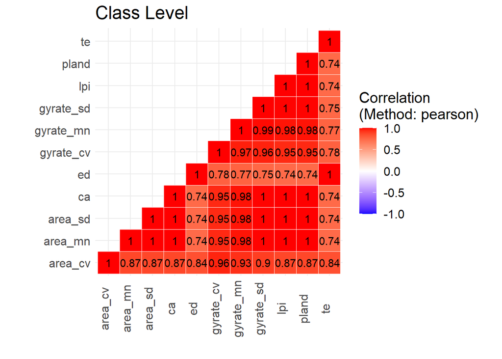

```r
show_correlation(data = metrics_comp, method = "pearson", labels = TRUE)
```

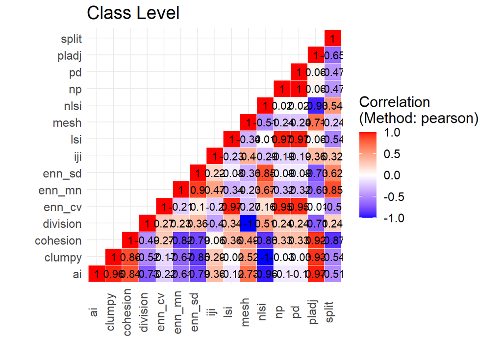

```r
show_correlation(data = metrics_config, method = "pearson", labels = TRUE)
```

Temos muitos valores e muitas métricas. Este se chama um “tiro no escuro”, algo cujo resultado se desconhece ou é imprevisível. Isso não é recomendado. Para fazer uma escolha melhor (mais robusta), seguindo princípios básicos da ciência, precisamos ler os estudos anteriores (artigos) para obter as métricas mais relevantes para nosso objetivo e a hipótese a ser testada. Com base em os estudos anteriores e os objetivos vamos incluir 8 métricas nos resultados.

# 7 Exportar as métricas

O próximo passo é comunicar os resultados obtidos. Para isso precisamos resumir e apresentar as métricas selecionadas em tabelas e figuras. Agora já fizemos os cálculos, as tabelas e figuras podem ser feitas no R ([figuras](https://www.youtube.com/watch?v=0RxEDDiRzQY)), tanto quanto em aplicativos diferentes (por exemplo tabelas atraves [“tabelas dinamicas”] no [Microsoft Excel](https://www.techtudo.com.br/dicas-e-tutoriais/2018/10/como-fazer-tabela-dinamica-no-excel.ghtml) ou [LibreOffice calc](https://www.youtube.com/watch?v=Mqi5BJwzAzo)). Mas por isso, primeiramente precisamos exportar os resultados (veja mais exemplos aqui: [Introdução ao R import-export](https://www.lampada.uerj.br/arquivosdb/_book2/importexport.html).

O arquivo vai sai no mesmo diretório do seu código (verifique com `getwd()`).

```r
bind_rows(metrics_comp, metrics_config) -> metricas_1985
write.csv2(metricas_1985, "metricas_lourenco_1985.csv", row.names=FALSE)
```

# 8 Preparando os resultados

A entrada de dados seria com as métricas da paisagem calculados anteriormente.

Vocês devem baixar o arquivo de Excel metricas_lourenco_1985.xlsx. Lembre-se, para facilitar, os dados deve ficar no mesmo diretório do seu código (verifique com `getwd()`).

No caso de um arquivo de Excel simples, a importação poderia ser feita através menu de “Import Dataset” na janela/panel “Environment” de Rstudio. Ou com linhas de código:

```r
metricas_1985 <- read_excel("metricas_lourenco_1985.xlsx")
metricas_1985

#  layer level class id    metric     value
#   <dbl> <chr> <dbl> <chr> <chr>      <dbl>
#     1 class     3 NA    area_cv  529.
#     1 class     4 NA    area_cv   22.3
#     1 class    11 NA    area_cv   71.2
```

Ou use o função `file.choose()`, que faz a busca para arquivos.

```r
metricas_1985 <- read_excel(file.choose())
metricas_1985
```

Os dados são padronizados (“tidy”), mas ainda não parece adequados para apresentação em tabelas ou figuras. Temos muitos valores e muitas métricas (listadas na coluna “metric”). Com base em os estudos anteriores e os objetivos vamos incluir 8 métricas (4 de composição e 4 de configuração).

Métricas de composição:

- mean patch area (`lsm_c_area_mn`) Área médio das manchas por classe.
- SD patch area (`lsm_c_area_sd`) Desvio padrão das áreas dos manchas por classe.
- class area percentage of landscape (`lsm_c_pland`) Porcentagem de área na paisagem por classe.
- largest patch index (`lsm_c_lpi`) Índice de maior mancha (proporção da paisagem).

Métricas de configuração:

- aggregation index (`lsm_c_ai`) Índice de agregação.
- patch cohesion index (`lsm_c_cohesion`) Índice de coesão das manchas.
- number of patches (`lsm_c_np`) Número de manchas.
- patch density (`lsm_c_pd`) Densidade de manchas.

Escolheremos (atraves um filtro) as métricas que queremos para obter uma tabela de dados. Mantendo os dados originais, assim sendo para acresentar mais métricas nos resultados, preciso somente acrescentar mais no codigo.

```r
# Arquivo com os nomes das classes
class_in <- "data/mapbiomas_6_legend.xlsx"
class_nomes <- read_excel(class_in)

# Especificar métricas desejados
met_comp <- c("pland", "lpi", "area_mn", "area_sd")
met_conf <- c("ai", "cohesion", "np", "pd")
met_todos <- c(met_comp, met_conf)

# Escholer métricas desejados do conjunto completo
metricas_1985 %>%
filter(metric %in% met_todos) %>%
left_join(class_nomes, by = c("class" = "aid")) -> metricas_nomes
```

# 9 Uma tabela versatil

Mas, ainda não tem uma coluna com os nomes das métricas. Portanto, solução simples é de exportar no formato de .csv e finalizar/editar no Excel / calc.

Outra opção que pode facilitar, particularmente quando pode há mudanças e revisões, é produzir a tabela no R. Aqui vamos repetir no R os passos que vocês conhecem com as ferramentas de Excel (arraste e solte, copiar-colar, filtro, tabela dinâmica).

Podemos organizar os dados que nos temos (objecto “metricas_nomes”) e apresentar em uma tabela em 3 passos: 1. Reorganização, 2. Montar a tabela e 3. Exportar a tabela em uma formato versatil, compativel com documentos (e.g. Word) e planilhas (e.g. Excel).

## 9.1 1. Reorganização

Escolhendo as colunas desejadas (`select`), reorganizando para as métricas ficam nas colunas (`pivot_wider`) e colocando as colunas novas na sequência desejada (`select`).

```r
metricas_nomes %>%
# Escholer métricas desejados do conjunto completo de métricas.
select(c(type_class, classe_descricao, hexadecimal_code,
metric, value)) %>%
# reorganizando
pivot_wider(names_from = metric, values_from = value) -> metricas_tab
```

## 9.2 2. Montar a tabela

Agora vamos produzir uma tabela simples e exportar em um formato versatil (html) para finalização no Word / Excel.

```r
# Nomes para as colunas
col_nomes <- c("Tipo", "Descrição","Área total", "Índice maior mancha",
"Número de manchas", "Área manchas (médio)", "Área manchas (DP)",
"Índice de agregação", "Índice de coesão", "Densidade de manchas")

# Valores para pontos decimais de cada coluna.
meu_digits <- c(0, 0, 0, 1, 0, 1, 1, 1, 1, 2)

metricas_tab %>%
# Colocar as colunas na sequência desejada.
select(type_class, classe_descricao, pland, lpi, np, area_mn, area_sd,
ai, cohesion, pd) %>%
# Especificar nomes para as colunas.
kable(col.names = col_nomes,
digits = meu_digits) %>%
kableExtra::kable_styling() #visualizar para verificar
```

| Tipo | Descrição | Área total | Índice maior mancha | Número de manchas | Área manchas (médio) | Área manchas (DP) | Índice de agregação | Índice de coesão | Densidade de manchas |
| --- | --- | --- | --- | --- | --- | --- | --- | --- | --- |
| natural | Formação Florestal | 99 | 98.9 | 28 | 5663.6 | 29940.5 | 99.8 | 100.0 | 0.02 |
| natural | Formação Savânica | 0 | 0.0 | 2 | 0.8 | 0.2 | 65.5 | 67.6 | 0.00 |
| natural | Campo Alagado e Área Pantanosa | 0 | 0.0 | 7 | 0.3 | 0.2 | 48.4 | 45.7 | 0.00 |
| natural | Formação Campestre | 0 | 0.0 | 246 | 2.2 | 3.8 | 68.1 | 86.1 | 0.15 |
| antropic | Pastagem | 0 | 0.0 | 262 | 2.1 | 3.8 | 63.2 | 86.4 | 0.16 |
| antropic | Mineração | 0 | 0.1 | 35 | 15.0 | 41.5 | 86.9 | 96.7 | 0.02 |
| natural | Rio, Lago e Oceano | 0 | 0.0 | 50 | 0.8 | 0.6 | 49.5 | 70.3 | 0.03 |

Parece um bom começo. Vamos exportar. Depois, pode finalizar no documento você está escrevendo (inserir -> objeto, e depois segue os passos) ou em uma planilha.

## 9.3 3. Exportar a tabela

```r
metricas_tab %>%
# Colocar as colunas na sequência desejada.
select(type_class, classe_descricao, pland, lpi, np, area_mn, area_sd,
ai, cohesion, pd) %>%
# Especificar nomes para as colunas.
kable(col.names = col_nomes,
digits = meu_digits) %>%
kableExtra::kable_styling() %>%
kableExtra::save_kable("tabela_metricas_1985.html")
```

E agora pode finalizar a tabela “tabela_metricas_1985.html” no documento você está escrevendo (inserir -> objeto, e depois segue passos) ou em uma [planilha](https://support.microsoft.com/pt-br/office/importar-dados-de-um-arquivo-csv-html-ou-de-texto-b62efe49-4d5b-4429-b788-e1211b5e90f6).

# 10 Uma figura elegante

Uma imagem vale mais que mil palavras. Portanto, gráficos/figuras/imagens são uma das mais importantes formas de comunicar a ciência.

Como exemplo ilustrativo, aqui vamos produzir gráficos comparando métricas de composição e configuração da paisagem ao redor do Garimpo do Lourenço.

É uma boa ideia gastar bastante tempo para tornar figuras científicas as mais informativas e atraentes possíveis. Escusado será dizer que a precisão empírica é primordial. E por isso, o que fica excluído/omitido é tão importante quanto o que foi incluído. Para ajudar, você deve se perguntar o seguinte ao criar uma figura: eu apresentaria essa figura em uma apresentação para um grupo de colegas? Eu o apresentaria a um público de não especialistas? Eu gostaria que essa figura aparecesse em um artigo de notícias sobre meu trabalho? É claro que todos esses locais exigem diferentes graus de precisão, complexidade e estética, mas uma boa figura deve servir para educar simultaneamente públicos muito diferentes.

Tabelas versus gráficos — A primeira pergunta que você deve se fazer é se você pode transformar aquela tabela (chata e feia) em algum tipo de gráfico. Você realmente precisa dessa tabela no texto principal? Você não pode simplesmente traduzir as entradas das células em um gráfico de barras/colunas/xy? Se você pode, você deve. Quando uma tabela não pode ser facilmente traduzida em uma figura, na maioria das vezes a provavelmente pertence às Informações Suplementares/Anexos/Apêndices.

## 10.1 Gráfico de barra

Primeiramente, vamos produzir uma gráfico de barra comparando a proporção que cada classe representa na paisagem.

```r
# Inclundo cores conforme legenda da Mapbiomas Coleção 6
# Legenda nomes ordem alfabetica
classe_cores <- c("Campo Alagado e Área Pantanosa" = "#45C2A5",
"Formação Campestre" = "#B8AF4F",
"Formação Florestal" = "#006400",
"Formação Savânica" = "#00ff00",
"Mineração" = "#af2a2a",
"Pastagem" = "#FFD966",
"Rio, Lago e Oceano" = "#0000FF")
```

E agora o grafico…….

```r
# Grafico de barra basica
metricas_tab %>%
mutate(class_prop = pland) %>%
ggplot(aes(x = classe_descricao, y = class_prop)) +
geom_col()


# Agora com ajustes
# Agrupando por tipo (natural e antropico)
# Com cores conforme legenda da Mapbiomas Coleção 6
# Corrigindo texto dos eixos.
# Mudar posição da leganda para o texto com nomes longas encaixar.
metricas_tab %>%
mutate(class_prop = pland) %>%
ggplot(aes(x = type_class, y = class_prop,
fill = classe_descricao)) +
scale_fill_manual("classe", values = classe_cores) +
geom_col(position = position_dodge2(width = 1)) +
coord_flip() +
labs(title = "MapBiomas cobertura da terra",
subtitle = "Entorno do Garimpo do Lorenço 1985",
y = "Proporção da paisagem (%)",
x = "") +
theme(legend.position="bottom") +
guides(fill = guide_legend(nrow = 4))
```

Uma imagem vale mais que mil palavras:

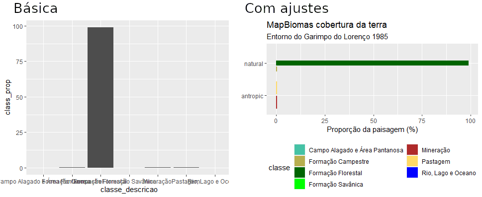

Mas existe uma separação grande na faixa de valores e ainda é difícil de ver todas as classes. Temos uma distribuição com valores muito mais altos comparada com os outros. extremos. Uma solução seria uma transformação (por exemplo “log”), assim os valores ficarem mais proximos.

## 10.2 Gráfico de boxplot

Agora com uma métrica de configuração:

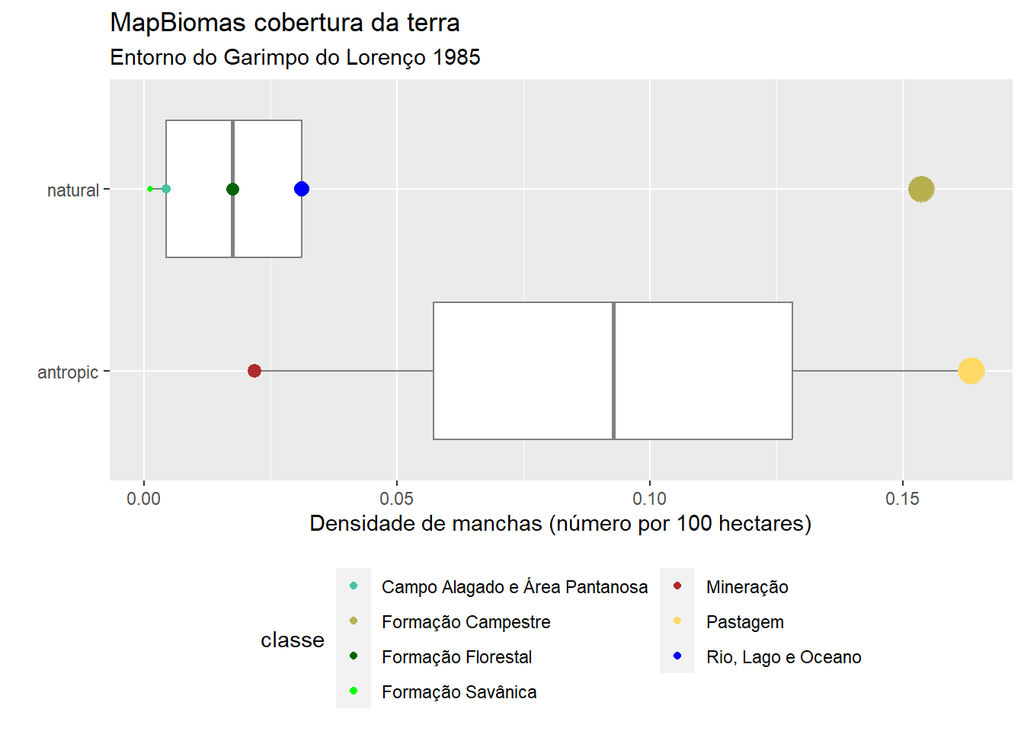

```r
# Métrica de configuração: Densidade de manchas (coluna "pd").
# Agrupando por tipo (natural e antrópico)
# Incluindo boxplot indicando tendência central (mediano)
# Com cores conforme legenda da Mapbiomas Coleção 6
# Tamanho dos pontos proporcional o numero de manchas
# Corrigindo texto dos eixos.
# Mudar posição da leganda para o texto com nomes longas encaixar.
metricas_tab %>%
ggplot(aes(x = type_class, y = pd)) +
geom_boxplot(colour = "grey50") +
geom_point(aes(size = np, colour = classe_descricao)) +
scale_color_manual("classe", values = classe_cores) +
scale_size(guide = "none") +
coord_flip() +
labs(title = "MapBiomas cobertura da terra",
subtitle = "Entorno do Garimpo do Lorenço 1985",
y = "Densidade de manchas (número por 100 hectares)",
x = "") +
theme(legend.position="bottom") +
guides(col = guide_legend(nrow = 4))
```

# 11 Comparação entre anos

Calcular as métricas para 3 anos.

```r
# metricas desejados
what_metricas <- c("lsm_c_pland", "lsm_c_lpi", "lsm_c_area_mn", "lsm_c_area_sd",
                   "lsm_c_ai", "lsm_c_cohesion", "lsm_c_np", "lsm_c_pd")
# rodar
metricas_anos <- sample_lsm(landscape = mapbiomas_85a20,
                            y = acesso_buffers,
                           plot_id = data.frame(acesso_buffers)[, 'raio_km'],
                             what = what_metricas,
                           edge_depth = 1)

# Organizar dados
# Dados rferentes os buffers
resultados_anos <- acesso_buffers %>%
  left_join(metricas_anos %>%
              dplyr::mutate(value = round(value,2),
         ano = case_when(layer==1 ~1985,
                         layer==2~2003,
                         layer==3~2020)) %>%
              dplyr::select(ano, plot_id, class, metric, value),
            by=c("raio_km"="plot_id"))
# Dados referentes os classes
resultados_anos <- resultados_anos %>%
left_join(class_nomes, by = c("class" = "aid"))
```

Agora grafico de barra com varios anos

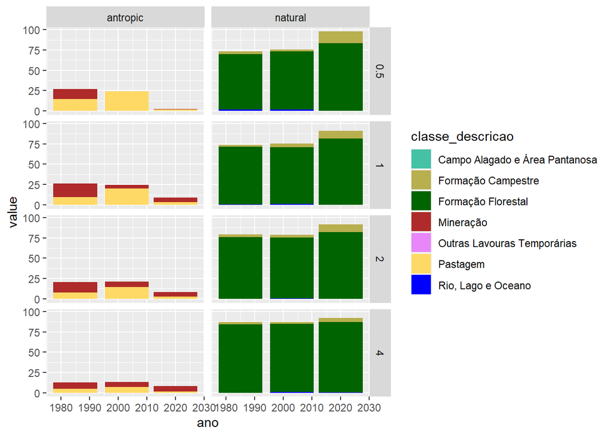

```r
# It's recommended to use a named vector
# Legenda nomes ordem alfabetica
classe_cores <- c("Campo Alagado e Área Pantanosa" = "#45C2A5",
"Formação Campestre" = "#B8AF4F",
"Formação Florestal" = "#006400",
"Formação Savânica" = "#00ff00",
"Mineração" = "#af2a2a",
"Pastagem" = "#FFD966",
"Rio, Lago e Oceano" = "#0000FF",
"Outras Lavouras Temporárias" = "#e787f8")

resultados_anos %>%
  mutate(rcor = paste("#", hexadecimal_code, sep="")) %>%
  filter(metric=="pland") %>%
  ggplot(aes(x=ano, y=value)) +
  geom_col(position="stack", aes(fill=classe_descricao)) +
  scale_fill_manual(values = classe_cores) +
  facet_grid(raio_km~type_class)
```

Agora com “pland” e densidade de manchas juntos.

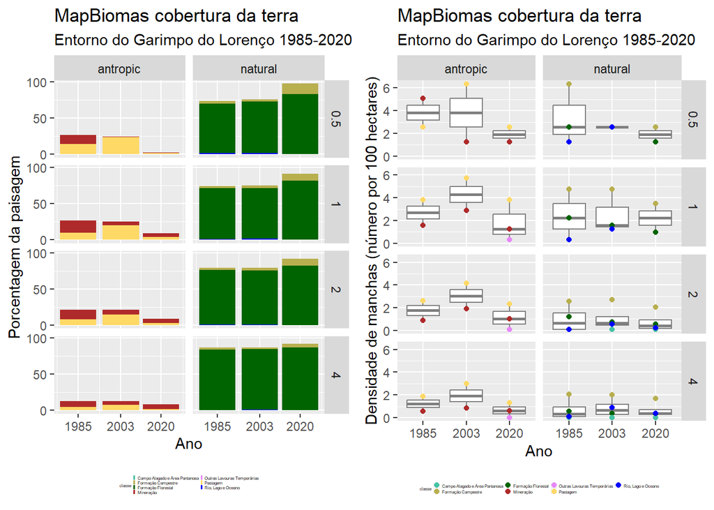

```r
resultados_anos %>%
  mutate(rcor = paste("#", hexadecimal_code, sep="")) %>%
  filter(metric=="pland") %>%
  ggplot(aes(x=ano, y=value)) +
  geom_col(position="stack", aes(fill=classe_descricao)) +
  scale_fill_manual("classe", values = classe_cores) +
  scale_y_continuous(breaks=c(0,50,100)) +
  scale_x_continuous(breaks=c(1985,2003, 2020)) +
  facet_grid(raio_km~type_class) +
  labs(title = "MapBiomas cobertura da terra",
subtitle = "Entorno do Garimpo do Lorenço 1985-2020",
y = "Porcentagem da paisagem",
x = "Ano") +
theme(legend.position="bottom",
      legend.title = element_text(size = 3),
              legend.text  = element_text(size = 3),
              legend.key.size = unit(0.1, "lines")) +
guides(fill = guide_legend(nrow = 4)) -> fig_pland

# Densidade de manchas
resultados_anos %>%
  mutate(rcor = paste("#", hexadecimal_code, sep="")) %>%
  filter(metric=="pd") %>%
ggplot(aes(x = factor(ano), y = value)) +
geom_boxplot(colour = "grey50") +
geom_point(aes(colour = classe_descricao)) +
scale_color_manual("classe", values = classe_cores) +
scale_size(guide = "none") +
facet_grid(raio_km~type_class) +
labs(title = "MapBiomas cobertura da terra",
subtitle = "Entorno do Garimpo do Lorenço 1985-2020",
y = "Densidade de manchas (número por 100 hectares)",
x = "Ano") +
theme(legend.position="bottom",
      legend.title = element_text(size = 3),
              legend.text  = element_text(size = 3),
              legend.key.size = unit(0.1, "lines")) +
guides(fill = guide_legend(nrow = 4)) -> fig_pd

grid.arrange(fig_pland, fig_pd, nrow=1)
```

# 12 Conclusões e próximos passos

Os resultados apresentados na figura anterior não segam os resultados esperados que a cobertura de classes antrópicos ia aumentar ao longo do tempo. Para entender melhor os padores, precisamos:

- Verficar padrões nas outras metricas calculados
- Verficar padrões com mais anos
- Verficar padrões usando poligonos/pontos dos processos de mineração (dados no SIGMINE https://www.gov.br/anm/pt-br e https://app.anm.gov.br/dadosabertos/SIGMINE/PROCESSOS_MINERARIOS/)

Alem disso, seria relevante buscar complementar os dados de MapBiomas com uma classificação supervisionado usando imagens de Sentinel-2 (exemplo com QGIS Semi-Automatic Classification plugin aqui: https://fromgistors.blogspot.com/2016/09/basic-tutorial-2.html). Assim para aumentar a precisão dos resultados.

Uma forma alternativa para visualização as mudanças entre anos seria um diagrama “Sankey”/“Alluvial”. Como exemplo, veja figura 3 no artigo “Rapid land use conversion in the Cerrado has affected water transparency in a hotspot of ecotourism, Bonito, Brazil” https://doi.org/10.1177/19400829221127087 .

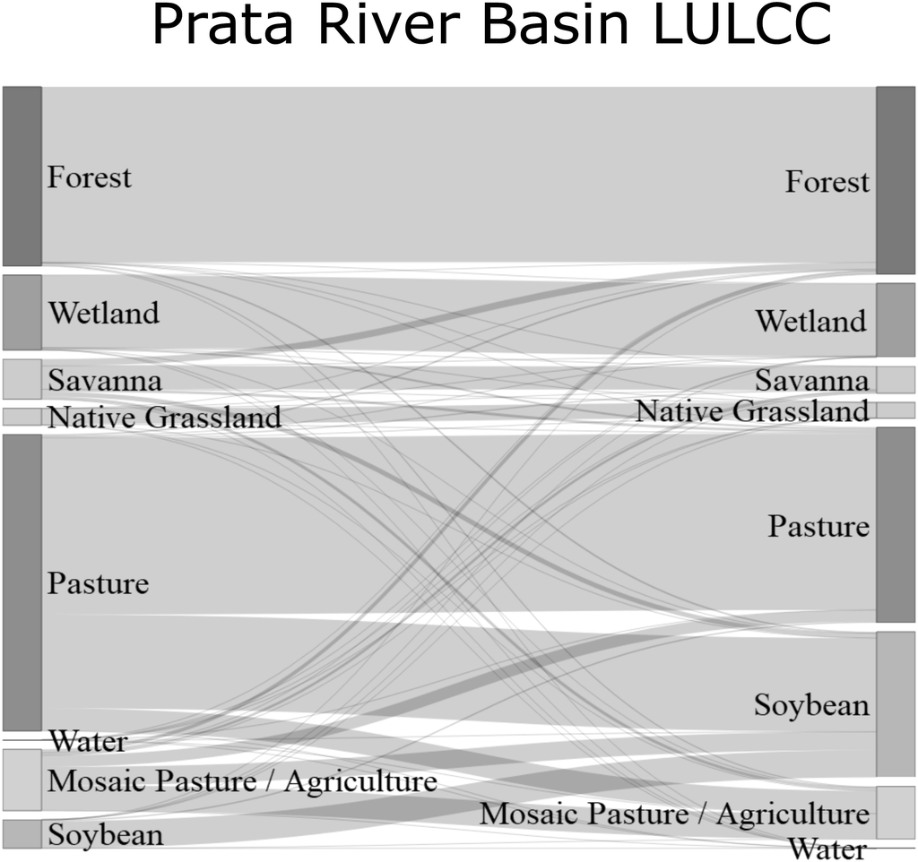

Figura 12.1: Diagrama Sankey mostrando a mudança de uso da terra na bacia do rio Prata entre 2010 (lado esquerdo) e 2020 (lado direto). Fonte: Figura 3. Chiaravalloti et. al. 2022. Tropical Conservation Science. doi:10.1177/19400829221127087

No R pode fazer com o pacote “networkD3” segue tutoriais:

- https://www.displayr.com/sankey-diagrams-r/
- https://epirhandbook.com/en/diagrams-and-charts.html#alluvialsankey-diagrams
- https://rpubs.com/droach/CPP526-codethrough